# 03 - Role Classification and Model Evaluation

## Executive Summary

This analysis develops and evaluates supervised classification models to predict player roles (Lurker, Spacetaker, Anchor, Rotator, AWPer) from behavioural and positional statistics.

**Outcome:** Identified champion models for both sides and a diagnostic framework for validating player roles.

**Note:** All analyses are performed separately for T-side and CT-side to preserve tactical context.

**Data Note:** The input dataset has been corrected, but for this classification analysis we **deliberately inject** the original mislabels (e.g., HooXi, Spinx) to demonstrate the model's diagnostic capabilities. We use these "controlled errors" to verify if the model can flag inconsistent labels.

## Objectives

**1. Experimental Design (Cross-Validation)**  
Establish a rigorous **4-split $\times$ 20-repeat Nested Cross-Validation** strategy (80 total folds) to ensure stable performance estimates given the small sample size ($N=84$).

**2. Baseline & Feature Ablation**  
Evaluate Logistic Regression baselines across four feature sets (Raw, Orthogonal, Residuals, Full) to manage multicollinearity and establish a performance floor.

**3. Sensitivity Analysis**  
Quantify the impact of ambiguous roles (Half-Lurker, Mixed) on classification performance to determine if the model struggles with features or with fuzzy definitions.

**4. Advanced Modelling**  
Benchmark non-linear models (SVM, Random Forest, XGBoost) against the linear baseline using nested cross-validation to identify the optimal classifier for each side.

**5. Interpretation & Diagnosis**  
Use **SHAP values**, **Waterfall plots**, and **Prediction Confidence** analysis to explain model decisions and diagnose specific misclassification patterns (e.g., the IGL-Centrality phenomena).

## 1. Setup and Experimental Design

**TL;DR:** Configure the analysis environment, load the processed dataset, define the cross-validation strategy, specify feature sets for ablation, and initialise the scaling pipeline.

**Methodology Notes**

**Cross-Validation Strategy:**

- **4 splits × 20 repeats = 80 total folds** provides robust performance estimates while maintaining reasonable computational cost
- Stratified K-Fold ensures class balance is preserved in each fold, critical for small sample sizes
- The same CV splits will be reused across all models to enable fair comparison

**Feature Set Definitions:**

- **Raw Features:** All original behavioural (TAPD, OAP, PODT, POKT) and positional (ADNT, ADAT) metrics. Baseline with multicollinearity (r ≈ 0.92 between ADNT and ADAT on T-side, r ≈ 0.78 on CT-side).
- **Orthogonal Features:** Uses ADNT + adat_residual (orthogonal pair, ρ ≈ 0.00). Replaces ADAT with its residual whilst keeping ADNT, eliminating multicollinearity between positional features whilst retaining both positioning dimensions.
- **Residual Features:** Uses only adat_residual (drops ADNT entirely). Tests whether the residual alone is sufficient for role discrimination.
- **Full Features:** All behavioural features + all three positioning features (ADNT, ADAT, adat_residual). Tests whether tree-based models can leverage multicollinearity better than linear models.
- Feature sets are **side-specific**: T-side feature sets use `*_t` suffix (e.g., `tapd_t`, `adnt_t`, `adat_residual_t`), CT-side feature sets use `*_ct` suffix (e.g., `tapd_ct`, `adnt_ct`, `adat_residual_ct`).

**Scaling Pipeline:**

- StandardScaler will be applied within cross-validation loops to prevent data leakage
- Scaling is fit only on training folds and applied to validation folds

**Side-Specific Modelling:**

- **All models will be run for both T-side and CT-side separately**
- T-side models use T-side features (`*_t`) and predict `role_t`
- CT-side models use CT-side features (`*_ct`) and predict `role_ct`
- This preserves tactical context and enables side-specific feature set selection and model comparison

```
(WindowsPath('P:/cs2-playstyle-analysis-2024'),
 WindowsPath('P:/cs2-playstyle-analysis-2024/data/processed/cs2_playstyles_2024_with_residuals.parquet'),
 WindowsPath('P:/cs2-playstyle-analysis-2024/results/classification/figures'),
 WindowsPath('P:/cs2-playstyle-analysis-2024/results/classification/tables'))
```

### Load Dataset

Load the processed dataset with engineered residual features and verify role distributions.

```
After filtering (MIN_MAPS=40): 84 players

> [DIAGNOSTIC SETUP] Injected deliberate CT-role errors for HooXi (Mixed->Anchor) and Spinx (Rotator->Anchor).
Shape: (84, 27)
```

|  | steamid | player_name | team_clan_name | map_count | tapd_ct | tapd_t | tapd_overall | oap_ct | oap_t | oap_overall | podt_ct | podt_t | podt_overall | pokt_ct | pokt_t | pokt_overall | adnt_rank_ct | adnt_rank_t | adnt_rank_overall | adat_rank_ct | adat_rank_t | adat_rank_overall | role_overall | role_t | role_ct | adat_residual_t | adat_residual_ct |
| --- | --- | --- | --- | --- | --- | --- | --- | --- | --- | --- | --- | --- | --- | --- | --- | --- | --- | --- | --- | --- | --- | --- | --- | --- | --- | --- | --- |
| 0 | 76561198041683378 | NiKo | G2 Esports | 158 | 60.952893 | 59.136540 | 60.136000 | 24.745965 | 24.093423 | 24.424242 | 21.020276 | 24.857741 | 22.507740 | 17.051295 | 21.586555 | 19.197995 | 0.562493 | 0.621199 | 0.593089 | 0.547525 | 0.695336 | 0.616046 | Lurker | Spacetaker | Rotator | 0.074668 | -0.014643 |
| 1 | 76561198012872053 | huNter | G2 Esports | 158 | 62.048685 | 62.871661 | 62.589800 | 16.852540 | 14.807692 | 15.847511 | 21.585198 | 27.994772 | 24.696747 | 17.195516 | 27.180894 | 22.538284 | 0.480859 | 0.643004 | 0.571875 | 0.406082 | 0.615021 | 0.455108 | Flex | Lurker | Rotator | -0.026997 | -0.073699 |
| 2 | 76561198074762801 | m0NESY | G2 Esports | 155 | 62.786553 | 66.632594 | 64.362519 | 23.914373 | 17.754078 | 20.873335 | 19.122381 | 23.094640 | 21.473108 | 17.397469 | 26.423178 | 21.056274 | 0.577785 | 0.423733 | 0.453028 | 0.515617 | 0.409889 | 0.427645 | AWPer | AWPer | AWPer | -0.017438 | -0.061984 |

```
Role distribution (T-side):
```

```
role_t
Spacetaker     31
Lurker         24
AWPer          17
Half-Lurker    12
Name: count, dtype: int64
```

```
Role distribution (CT-side):
```

```
role_ct
Rotator    27
Anchor     23
AWPer      17
Mixed      17
Name: count, dtype: int64
```

### Cross-Validation Strategy

**TL;DR:** Define a 4-split, 20-repeat Stratified K-Fold strategy (80 total folds) that will be reused across all models for fair comparison.

**Why This Strategy?**

The small sample size (N=84) requires a rigorous CV strategy to obtain reliable performance estimates. Using 4 splits provides reasonable training set sizes (~63 samples in each training fold, ~21 samples in each test fold) while 20 repeats ensures statistical stability through multiple independent evaluations. Stratified sampling preserves class balance across all folds.

```
Cross-validation strategy: 4 splits × 20 repeats = 80 total folds per side
```

### Feature Sets

**TL;DR:** Define four feature sets for ablation testing: Raw (baseline), Orthogonal (ADNT + adat_residual, no positional multicollinearity), Residuals (adat_residual only), and Full (all positioning features).

**Feature Set Definitions**

**Raw Features:** All original behavioural and positional metrics. Includes both ADNT and ADAT despite their high correlation (r ≈ 0.92 on T-side, r ≈ 0.78 on CT-side). Baseline with multicollinearity among positional features (ADNT/ADAT).

**Orthogonal Features:** Uses ADNT + adat_residual (orthogonal pair, ρ ≈ 0.00). Eliminates multicollinearity while retaining both positioning dimensions. Tests whether removing positional multicollinearity improves model stability.

**Residual Features:** Uses only adat_residual (drops ADNT entirely). Tests whether the residual alone is sufficient, or if ADNT provides additional signal.

**Full Features:** All behavioural + all three positioning features (ADNT, ADAT, adat_residual). Tests whether including both ADAT and ADAT_residual produces meaningful performance improvement. Tree-based models may handle multicollinearity better than linear models.

**Side-Specific Implementation:** Feature sets are generated separately for T-side (using `*_t` suffix) and CT-side (using `*_ct` suffix). All four sets will be evaluated for both sides.

```
============================================================
T-SIDE FEATURE SETS
============================================================

Raw Features (6 features):
['tapd_t', 'oap_t', 'podt_t', 'pokt_t', 'adnt_rank_t', 'adat_rank_t']

Orthogonal Features (6 features):
['tapd_t', 'oap_t', 'podt_t', 'pokt_t', 'adnt_rank_t', 'adat_residual_t']

Residuals Features (5 features):
['tapd_t', 'oap_t', 'podt_t', 'pokt_t', 'adat_residual_t']

Full Features (7 features):
['tapd_t', 'oap_t', 'podt_t', 'pokt_t', 'adnt_rank_t', 'adat_rank_t', 'adat_residual_t']

============================================================
CT-SIDE FEATURE SETS
============================================================

Raw Features (6 features):
['tapd_ct', 'oap_ct', 'podt_ct', 'pokt_ct', 'adnt_rank_ct', 'adat_rank_ct']

Orthogonal Features (6 features):
['tapd_ct', 'oap_ct', 'podt_ct', 'pokt_ct', 'adnt_rank_ct', 'adat_residual_ct']

Residuals Features (5 features):
['tapd_ct', 'oap_ct', 'podt_ct', 'pokt_ct', 'adat_residual_ct']

Full Features (7 features):
['tapd_ct', 'oap_ct', 'podt_ct', 'pokt_ct', 'adnt_rank_ct', 'adat_rank_ct', 'adat_residual_ct']
```

**Setup Complete**

- Dataset loaded: 84 players with all expected residual features
- CV strategy defined: 80 total folds (4 splits × 20 repeats)
- Four feature sets prepared for ablation (Raw, Orthogonal, Residuals, Full) for both sides
- Scaling pipeline ready (applied within CV loops to prevent data leakage)

Ready for baseline modelling.

## 2. Baseline Models & Feature Selection

**TL;DR:** Establish baselines using Dummy and Logistic Regression across all feature sets. Select Orthogonal feature set for parsimony. Diagnose per-class performance, then exclude ambiguous roles to test core role separability. Visualise feature–role associations from the filtered dataset.

**Methodology Details**

**Baseline Evaluation:**

- **Models:** Dummy Classifier (stratified baseline) vs. Logistic Regression (linear baseline)
- **Feature Sets:** Four sets evaluated to handle multicollinearity between ADNT and ADAT:
  - *Raw*: All features (high multicollinearity)
  - *Orthogonal*: ADNT + adat_residual (uncorrelated positioning dimensions)
  - *Residuals*: adat_residual only (tests if ADNT is redundant)
  - *Full*: All features (tests if models handle multicollinearity well)
- **Metric:** F1-Macro (mean of per-class F1 scores) to handle class imbalance

**Sensitivity Analysis:**

- Per-class metrics reveal that ambiguous roles (Half-Lurker on T-side, Mixed on CT-side) have poor performance, suggesting they blur boundaries between core playstyles
- We re-evaluate after excluding these roles to test whether the model struggles due to weak features or simply because these roles are inherently fuzzy
- **Coefficient Visualisation:** We visualise feature weights from the filtered dataset to see the clearest signal of what defines each core role

### Baseline Models & Feature Selection

Run baseline models across all feature sets for both sides, then select the optimal feature set.

```
Running baselines for T-side...
Running baselines for CT-side...

============================================================
FEATURE SET COMPARISON (Logistic Regression F1-Macro)
============================================================

T-Side:
```

|  | Side | Model | Feature_Set | Mean_F1_Macro | Std_F1_Macro | Mean_Accuracy | Std_Accuracy |
| --- | --- | --- | --- | --- | --- | --- | --- |
| 0 | T-Side | LogisticRegression | Full | 0.693830 | 0.088836 | 0.770833 | 0.068633 |
| 1 | T-Side | LogisticRegression | Raw | 0.685843 | 0.085449 | 0.767857 | 0.069160 |
| 2 | T-Side | LogisticRegression | Orthogonal | 0.674325 | 0.074047 | 0.763690 | 0.063640 |
| 3 | T-Side | LogisticRegression | Residuals | 0.466390 | 0.085475 | 0.579762 | 0.083427 |
| 4 | T-Side | Dummy | Orthogonal | 0.253056 | 0.110655 | 0.305357 | 0.110322 |
| 5 | T-Side | Dummy | Raw | 0.253056 | 0.110655 | 0.305357 | 0.110322 |
| 6 | T-Side | Dummy | Residuals | 0.253056 | 0.110655 | 0.305357 | 0.110322 |
| 7 | T-Side | Dummy | Full | 0.253056 | 0.110655 | 0.305357 | 0.110322 |

```
CT-Side:
```

|  | Side | Model | Feature_Set | Mean_F1_Macro | Std_F1_Macro | Mean_Accuracy | Std_Accuracy |
| --- | --- | --- | --- | --- | --- | --- | --- |
| 0 | CT-Side | LogisticRegression | Raw | 0.508231 | 0.082315 | 0.564881 | 0.075196 |
| 1 | CT-Side | LogisticRegression | Full | 0.501163 | 0.085292 | 0.556548 | 0.084714 |
| 2 | CT-Side | LogisticRegression | Orthogonal | 0.495041 | 0.078242 | 0.554167 | 0.079769 |
| 3 | CT-Side | LogisticRegression | Residuals | 0.400822 | 0.077293 | 0.454167 | 0.082115 |
| 4 | CT-Side | Dummy | Orthogonal | 0.255153 | 0.090947 | 0.283333 | 0.092490 |
| 5 | CT-Side | Dummy | Raw | 0.255153 | 0.090947 | 0.283333 | 0.092490 |
| 6 | CT-Side | Dummy | Residuals | 0.255153 | 0.090947 | 0.283333 | 0.092490 |
| 7 | CT-Side | Dummy | Full | 0.255153 | 0.090947 | 0.283333 | 0.092490 |

```
Comparison table saved to: P:\cs2-playstyle-analysis-2024\results\classification\tables\feature_set_comparison.csv
```

### Feature Set Selection: Baseline Analysis

**Decision:** Use **Orthogonal** for interpretation (coefficient analysis, sensitivity) but carry **Raw**, **Orthogonal**, and **Full** forward to the model comparison phase.

**Detailed Analysis**

**1. Baseline Comparison**  
Logistic Regression substantially outperforms the stratified dummy classifier across all feature sets:

- **T-Side:** LogReg (0.674 F1) vs. Dummy (0.253 F1) — 166% improvement
- **CT-Side:** LogReg (0.495 F1) vs. Dummy (0.255 F1) — 94% improvement

**2. Feature Set Performance**  
Performance differences between Orthogonal, Raw, and Full are almost negligible:

- **T-Side:** Full (0.694) > Raw (0.686) > Orthogonal (0.674) — differences within 0.02 F1
- **CT-Side:** Raw (0.508) > Full (0.501) > Orthogonal (0.495) — differences within 0.013 F1

All three configurations show overlapping standard deviations, indicating no statistically meaningful advantage for Full or Raw.

**3. Why Multiple Feature Sets for Model Comparison?**  
Although Orthogonal is preferred for interpretation, we retain all three sets for the advanced model phase because:

- **Multicollinearity affects LogReg more than trees/SVMs:** The coefficient instability caused by correlated features (ADNT ↔ ADAT, r ≈ 0.92) is a LogReg-specific issue. Tree-based models (XGBoost, RF) and SVMs are robust to multicollinearity and may extract additional signal from Raw/Full.
- **Differences are within noise:** With N=84, a 0.02 F1 difference corresponds to ~1–2 players. The sets are effectively tied, so committing to one risks leaving performance on the table.
- **Minimal cost:** Testing three feature sets adds negligible compute overhead and ensures we identify the optimal configuration for each model class.

**4. Interpretation vs. Prediction**

- **Orthogonal** will be used for the following sensitivity analysis and coefficient visualisation (Section 2) to ensure stable, interpretable feature–role associations.
- **All three sets** will be benchmarked in the model comparison (Section 3) to maximise understanding of predictive performance.

**5. CT-Side Signal Limitations**  
CT-side performance remains modest (F1 ≈ 0.50) across all feature sets, suggesting the CT role taxonomy is harder to discriminate with our playstyle metrics alone. This likely reflects the situational nature of CT roles (e.g., map-specific assignments, dynamic rotations). Predictions should be treated as exploratory pending richer CT-specific features.

```
Selected: {'t': 'Orthogonal', 'ct': 'Orthogonal'}
```

### Per-Class Performance Diagnosis

Evaluate precision, recall, and F1 per role to identify which roles are harder/easier to predict.

**Why Per-Class Metrics?**

F1-Macro provides an overall performance summary but masks per-class differences. Per-class metrics reveal whether the model struggles with specific roles (e.g., minority classes or ambiguous definitions) and help identify precision–recall trade-offs.

```
T-Side Per-Class Metrics (Full Dataset):
```

|  | role | precision_mean | precision_std | recall_mean | recall_std | f1_mean | f1_std |
| --- | --- | --- | --- | --- | --- | --- | --- |
| 1 | Half-Lurker | 0.253542 | 0.335552 | 0.183333 | 0.240947 | 0.196806 | 0.240360 |
| 3 | Spacetaker | 0.763843 | 0.107101 | 0.843527 | 0.137287 | 0.793073 | 0.094453 |
| 2 | Lurker | 0.795965 | 0.141438 | 0.883333 | 0.127475 | 0.824978 | 0.094273 |
| 0 | AWPer | 0.930179 | 0.114774 | 0.861250 | 0.173561 | 0.882445 | 0.124662 |

```
Full table saved to: P:\cs2-playstyle-analysis-2024\results\classification\tables\per_class_metrics_t.csv

CT-Side Per-Class Metrics (Full Dataset):
```

|  | role | precision_mean | precision_std | recall_mean | recall_std | f1_mean | f1_std |
| --- | --- | --- | --- | --- | --- | --- | --- |
| 2 | Mixed | 0.186280 | 0.265918 | 0.106875 | 0.135264 | 0.126678 | 0.155462 |
| 0 | AWPer | 0.637991 | 0.214509 | 0.597500 | 0.245701 | 0.588312 | 0.190074 |
| 3 | Rotator | 0.604961 | 0.136919 | 0.689286 | 0.153239 | 0.631406 | 0.112602 |
| 1 | Anchor | 0.604894 | 0.142322 | 0.697083 | 0.182361 | 0.633769 | 0.122807 |

```
Full table saved to: P:\cs2-playstyle-analysis-2024\results\classification\tables\per_class_metrics_ct.csv
```

**Key Finding**

Ambiguous roles (Half-Lurker on T-side, Mixed on CT-side) show particularly poor F1 scores, suggesting they blur boundaries between core playstyles and aren't a distinct archetype. This justifies filtering them to test whether the model can better separate clearly-defined core roles.

### Sensitivity Analysis: Core Role Separability

Exclude ambiguous roles to test whether the model struggles due to weak features or simply because these roles are inherently fuzzy. If performance improves substantially, it confirms these roles introduce systematic confusion rather than revealing feature limitations.

```
=== Sensitivity Analysis: Impact of Excluding Ambiguous Roles ===
```

|  | Side | Excluded_Role | N_Full | N_Filtered | F1_Full | F1_Filtered | Delta |
| --- | --- | --- | --- | --- | --- | --- | --- |
| 0 | T-Side | Half-Lurker | 84 | 72 | 0.674325 | 0.921120 | 0.246794 |
| 1 | CT-Side | Mixed | 84 | 67 | 0.495041 | 0.670192 | 0.175150 |

```
=== Per-Class Metrics (Core Roles Only) ===

T-Side (excluding Half-Lurker):
```

|  | role | precision_mean | precision_std | recall_mean | recall_std | f1_mean | f1_std |
| --- | --- | --- | --- | --- | --- | --- | --- |
| 1 | Lurker | 0.908631 | 0.097040 | 0.950000 | 0.080795 | 0.923538 | 0.061559 |
| 0 | AWPer | 0.962292 | 0.082653 | 0.899375 | 0.139305 | 0.922455 | 0.094451 |
| 2 | Spacetaker | 0.932222 | 0.075045 | 0.912723 | 0.099624 | 0.917367 | 0.064466 |

```
CT-Side (excluding Mixed):
```

|  | role | precision_mean | precision_std | recall_mean | recall_std | f1_mean | f1_std |
| --- | --- | --- | --- | --- | --- | --- | --- |
| 1 | Anchor | 0.807009 | 0.124657 | 0.760833 | 0.144316 | 0.769876 | 0.092408 |
| 2 | Rotator | 0.651553 | 0.158925 | 0.687202 | 0.186215 | 0.654556 | 0.137992 |
| 0 | AWPer | 0.655898 | 0.230986 | 0.575000 | 0.227211 | 0.586142 | 0.190224 |

**Result**

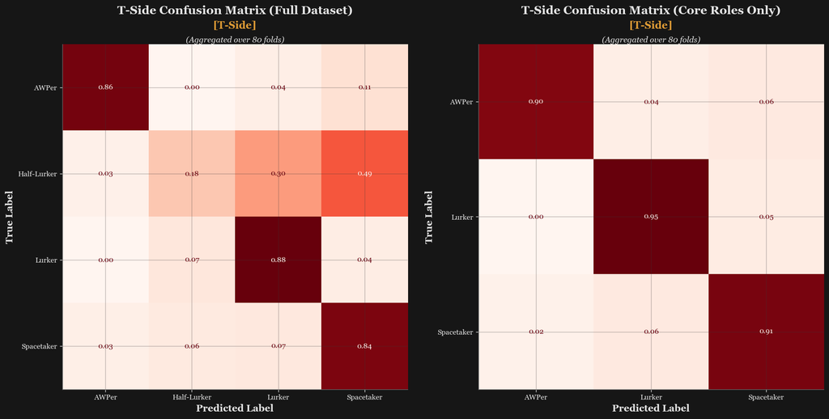

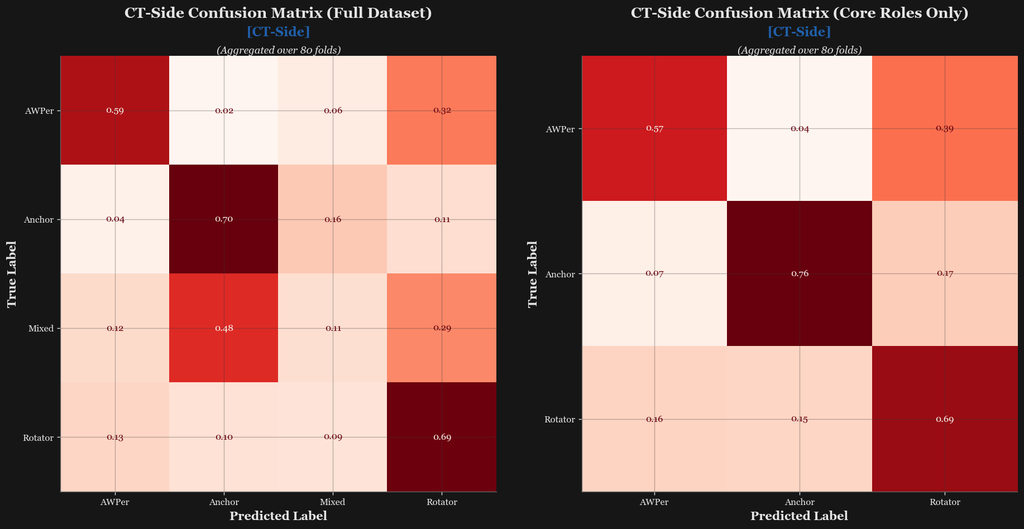

**Observations**

1. **CT-side AWPers are the least distinct core role**, with ~39% misclassified as Rotators even after excluding Mixed. This confusion is intrinsic—removing the ambiguous class barely changes AWPer recall (59%→57%). CT AWPers likely share rotational positioning behaviour that our features cannot separate.
2. **Ambiguous roles skew toward specific archetypes**: Half-Lurkers are predicted as Spacetakers (49%) more than Lurkers (30%), suggesting more aggressive tendencies than their name may suggest. Mixed players lean toward Anchor (48%) over Rotator (29%).
3. **T-side benefits more from filtering**: Lurker recall jumps from 88% to 95% when Half-Lurker is removed, indicating Half-Lurkers were "absorbing" correct Lurker predictions. CT-side gains are more modest.
4. **Confusion asymmetry reveals role distinctiveness**: Rotators are rarely misclassified as AWPers (13%), but AWPers are often misclassified as Rotators (32%). This suggests Rotators have a more unique behavioural signature while some AWPers exhibit rotator-like flexibility.

### Model Interpretation: Feature–Role Associations

Visualise Logistic Regression coefficients from the filtered dataset (core roles only) to reveal the clearest signal of what defines each archetype.

```
Generating T-side coefficients (excluding Half-Lurker)...
```

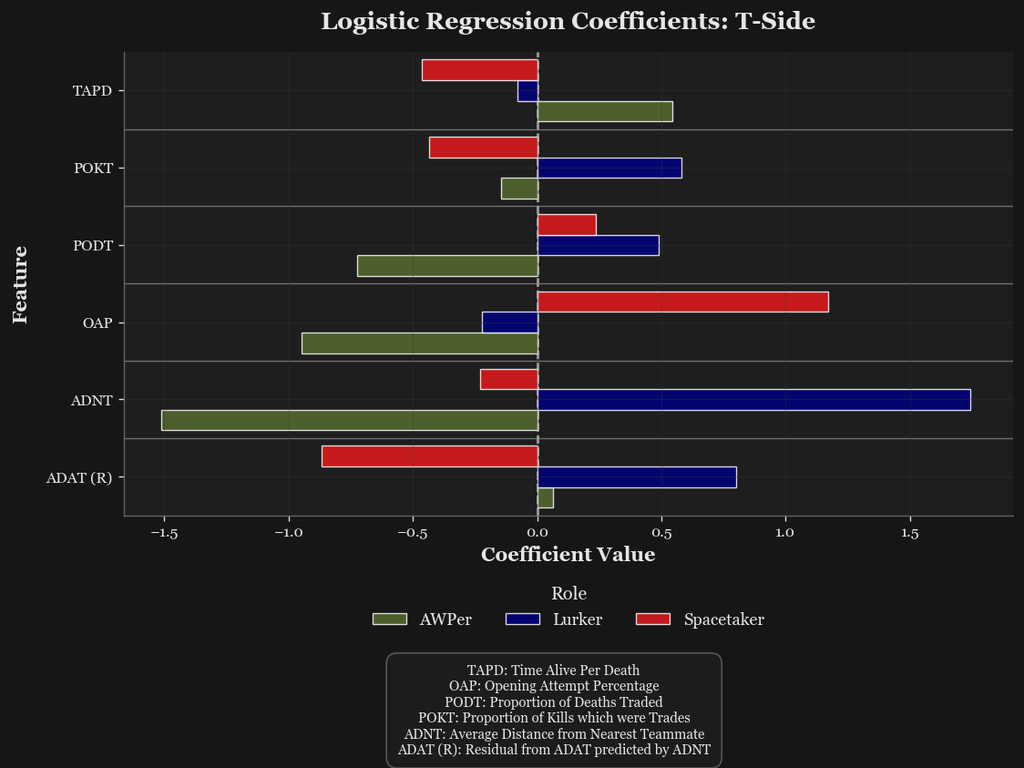

```
  Coefficients saved to: P:\cs2-playstyle-analysis-2024\results\classification\tables\logreg_coefficients_t_filtered.csv

Generating CT-side coefficients (excluding Mixed)...
```

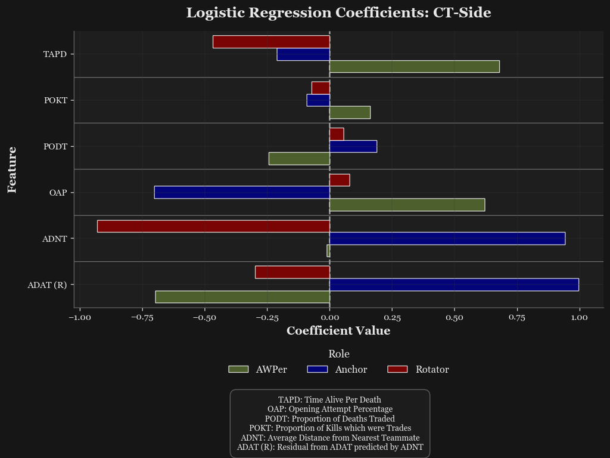

```
  Coefficients saved to: P:\cs2-playstyle-analysis-2024\results\classification\tables\logreg_coefficients_ct_filtered.csv
```

**Key Findings**

Coefficients reveal clear behavioural signatures:

- **Spacetakers (T):** High `oap` (opening attempts) and less `POKT` (trade kills)
- **Lurkers (T):** High `adnt` (isolation) and high `POKT` (trade kills)
- **AWPers: (T)** High `TAPD` (time alive), Low `ADNT` (positioning very close to teammates)
- **Anchors (CT):** High `ADNT` and `ADAT_Residual`, positioning very far from teammates
- **Rotators (CT):** Low `ADNT` (close to teammates) and low `TAPD` time alive.
- **AWPers: (CT)** High `TAPD` (time alive), relatively High `OAP` (due to "pick" kills)

These associations generally align with domain knowledge and findings from the EDA, validating the selected features.

### Summary & Interpretations

**Detailed Interpretations**

**Baseline Performance & Feature Selection:**

- Logistic Regression substantially outperforms Dummy Classifier, indicating features contain meaningful signal
- Performance differences between Raw, Orthogonal, and Full are negligible (within 0.02 F1, ~1 player difference at N=84)
- **Orthogonal** used for interpretation (sensitivity analysis, coefficients) because multicollinearity destabilises LogReg coefficients
- All three feature sets will be tested with advanced models, since tree-based methods (RF, XGBoost) and SVMs are robust to multicollinearity
- CT-side results remain modest (F1 ≈ 0.50). Treat predictions as exploratory pending richer features

**Core vs. Ambiguous Roles:**

- Per-class diagnosis revealed that ambiguous roles (Half-Lurker on T-side, Mixed on CT-side) are very hard to classify and blur boundaries between core playstyles
- Sensitivity analysis confirms these roles introduce systematic confusion: excluding them improves F1-Macro, validating the model can effectively distinguish clearly-defined core roles
- The performance improvement (Δ) quantifies the impact and confirms these are mixed states rather than distinct archetypes

**Feature–Role Associations:**

- Coefficient visualisation reflects clear behavioural signatures, analogous to findings in EDA (01_eda.ipynb): e.g.
  - **Spacetakers (T):** High `oap` (entry attempts)
  - **Lurkers (T):** High `adnt` (isolation)
  - **Anchors vs. Rotators (CT):** Distinguished by positioning metrics (packing density and mobility)
- These associations align with domain knowledge, validating the features and that the model picked up on playstyle differences.

**Next Steps:** The logistic regression baseline is strong (~0.69 F1 for T-side), but we proceed to **Section 3** to test whether non-linear models (SVM, Random Forest, XGBoost) can improve performance. All three feature sets (Raw, Orthogonal, Full) will be benchmarked since multicollinearity—which affects LogReg coefficient interpretation—is not a concern for tree-based models.

## 3. Advanced Model Comparison

**TL;DR:** Evaluate SVM, Random Forest, and XGBoost using Nested Cross-Validation. Compare performance across feature sets (Raw, Orthogonal, Full) to identify the champion model for further analysis.

**Methodology: Nested Cross-Validation**

**Why Nested CV?**  
With only 84 players, we cannot afford a separate holdout set for hyperparameter tuning. If we tuned hyperparameters on the same data used for evaluation, we would overfit to noise. Nested CV solves this:

- **Outer Loop (Evaluation):** Our existing 4-split × 20-repeat strategy (80 folds). This measures generalisation performance.
- **Inner Loop (Tuning):** Inside each outer training fold (~63 players), we run a 3-fold GridSearchCV to select the best hyperparameters.

**The Flow:**

**Hyperparameter Strategy:**  
We search broad, sensible ranges (orders of magnitude) rather than fine-grained values. With small data, finding a "stable region" matters more than pinpointing an exact optimum.

**Feature Sets:**  
We test Raw, Orthogonal, and Full for each model. Tree-based models (RF, XGBoost) and SVMs are robust to multicollinearity, so they may extract additional signal from correlated features.

**Note on Reported Hyperparameters:**  
Performance metrics (F1-Macro, standard deviation) are derived from the 80-fold Nested CV to ensure unbiased evaluation. The "Best Parameters" reported for each configuration (model + feature set + side) are derived from a final grid search run on the full filtered dataset for that side. This is standard practice: Nested CV validates the *search strategy* and provides unbiased performance estimates, while the final fit on all available data identifies the optimal hyperparameters for each configuration.

```
Section 3 setup complete. Ready for model evaluation.
```

### 3.1 Support Vector Machine (SVM)

**Why SVM?** SVMs excel with small datasets and high-dimensional feature spaces. The kernel trick allows them to find non-linear decision boundaries without explicit feature engineering. With balanced class weights, they handle imbalanced classes gracefully.

**Hyperparameter Grid:**

- `C` (Regularisation): [0.1, 1, 10, 100] — Controls the trade-off between margin width and misclassification. Lower C = smoother boundary.
- `kernel`: ['linear', 'rbf'] — Linear for simple boundaries, RBF for complex non-linear patterns.
- `gamma`: ['scale', 'auto'] — RBF kernel spread. 'scale' is generally preferred.
- `class_weight`: ['balanced'] — Adjusts weights inversely proportional to class frequencies.
- `probability`: [True] — Enables probability estimates (needed for later calibration/SHAP).

```
Running SVM with Nested CV...
Grid size: 16 combinations per inner CV

SVM Results:
```

|  | Side | Model | Feature_Set | Mean_F1 | Std_F1 | Mean_Accuracy | Std_Accuracy | Mean_Train_F1 | Std_Train_F1 | Mean_Fit_Time | Best_Params | All_Scores |
| --- | --- | --- | --- | --- | --- | --- | --- | --- | --- | --- | --- | --- |
| 0 | T-Side | SVM | Raw | 0.874 | 0.066 | 0.872 | 0.065 | 0.961 | 0.025 | 0.252 | {'C': 1, 'class_weight': 'balanced', 'gamma': ... | [1.0, 0.8766884531590414, 0.8384208384208384, ... |
| 1 | T-Side | SVM | Orthogonal | 0.913 | 0.053 | 0.910 | 0.054 | 0.962 | 0.017 | 0.090 | {'C': 0.1, 'class_weight': 'balanced', 'gamma'... | [0.9407407407407407, 0.9027777777777778, 0.889... |
| 2 | T-Side | SVM | Full | 0.907 | 0.056 | 0.903 | 0.057 | 0.965 | 0.020 | 0.059 | {'C': 0.1, 'class_weight': 'balanced', 'gamma'... | [1.0, 0.8303872053872053, 0.8384208384208384, ... |
| 3 | CT-Side | SVM | Raw | 0.704 | 0.098 | 0.711 | 0.095 | 0.867 | 0.060 | 0.069 | {'C': 1, 'class_weight': 'balanced', 'gamma': ... | [0.5285714285714286, 0.810966810966811, 0.7146... |
| 4 | CT-Side | SVM | Orthogonal | 0.693 | 0.093 | 0.699 | 0.092 | 0.868 | 0.062 | 0.071 | {'C': 1, 'class_weight': 'balanced', 'gamma': ... | [0.6813186813186812, 0.7523809523809524, 0.714... |
| 5 | CT-Side | SVM | Full | 0.708 | 0.091 | 0.715 | 0.089 | 0.875 | 0.058 | 0.067 | {'C': 0.1, 'class_weight': 'balanced', 'gamma'... | [0.6794871794871794, 0.810966810966811, 0.7146... |

### 3.2 Random Forest

**Why Random Forest?** Ensemble of decision trees that reduces overfitting through bagging and feature randomisation. Robust to outliers and handles non-linear relationships well. Provides built-in feature importance estimates.

**Hyperparameter Grid (Regularised for Small Data):**

```
Running Random Forest with Nested CV (Regularised Grid)...
Grid size: 9 combinations per inner CV

Random Forest Results:
```

|  | Side | Model | Feature_Set | Mean_F1 | Std_F1 | Mean_Accuracy | Std_Accuracy | Mean_Train_F1 | Std_Train_F1 | Mean_Fit_Time | Best_Params | All_Scores |
| --- | --- | --- | --- | --- | --- | --- | --- | --- | --- | --- | --- | --- |
| 0 | T-Side | RandomForest | Raw | 0.822 | 0.091 | 0.822 | 0.088 | 0.954 | 0.027 | 0.533 | {'class_weight': 'balanced', 'max_depth': 3, '... | [0.8857142857142857, 0.9500891265597149, 0.773... |
| 1 | T-Side | RandomForest | Orthogonal | 0.813 | 0.103 | 0.813 | 0.101 | 0.957 | 0.035 | 0.540 | {'class_weight': 'balanced', 'max_depth': 2, '... | [0.8363636363636363, 0.8962962962962964, 0.824... |
| 2 | T-Side | RandomForest | Full | 0.828 | 0.084 | 0.825 | 0.083 | 0.955 | 0.029 | 0.535 | {'class_weight': 'balanced', 'max_depth': 2, '... | [0.9407407407407407, 0.9500891265597149, 0.773... |
| 3 | CT-Side | RandomForest | Raw | 0.756 | 0.084 | 0.758 | 0.080 | 0.870 | 0.029 | 0.534 | {'class_weight': 'balanced', 'max_depth': 2, '... | [0.7579365079365079, 0.6892736892736893, 0.776... |
| 4 | CT-Side | RandomForest | Orthogonal | 0.751 | 0.090 | 0.755 | 0.087 | 0.861 | 0.034 | 0.560 | {'class_weight': 'balanced', 'max_depth': 2, '... | [0.6895104895104894, 0.7594405594405594, 0.714... |
| 5 | CT-Side | RandomForest | Full | 0.764 | 0.084 | 0.767 | 0.081 | 0.863 | 0.033 | 0.546 | {'class_weight': 'balanced', 'max_depth': 2, '... | [0.6897546897546897, 0.8773892773892774, 0.776... |

### 3.3 XGBoost

**Why XGBoost?** Gradient boosting builds trees sequentially, each correcting the errors of the previous. Often achieves state-of-the-art performance on tabular data. However, it is prone to overfitting on small datasets, so we use conservative hyperparameters with explicit regularisation.

**Hyperparameter Grid (Regularised):**

```
Running XGBoost with Nested CV...
Grid size: 12 combinations per inner CV

XGBoost Results:
```

|  | Side | Model | Feature_Set | Mean_F1 | Std_F1 | Mean_Accuracy | Std_Accuracy | Mean_Train_F1 | Std_Train_F1 | Mean_Fit_Time | Best_Params | All_Scores |
| --- | --- | --- | --- | --- | --- | --- | --- | --- | --- | --- | --- | --- |
| 0 | T-Side | XGBoost | Raw | 0.794 | 0.084 | 0.798 | 0.079 | 0.942 | 0.023 | 0.180 | {'eval_metric': 'mlogloss', 'learning_rate': 0... | [0.8857142857142857, 0.8850408850408851, 0.824... |
| 1 | T-Side | XGBoost | Orthogonal | 0.812 | 0.099 | 0.816 | 0.097 | 0.973 | 0.015 | 0.179 | {'eval_metric': 'mlogloss', 'learning_rate': 0... | [0.8169191919191919, 0.8962962962962964, 0.773... |
| 2 | T-Side | XGBoost | Full | 0.819 | 0.080 | 0.820 | 0.078 | 0.965 | 0.019 | 0.171 | {'eval_metric': 'mlogloss', 'learning_rate': 0... | [0.8857142857142857, 0.8850408850408851, 0.824... |
| 3 | CT-Side | XGBoost | Raw | 0.709 | 0.105 | 0.720 | 0.092 | 0.889 | 0.029 | 0.173 | {'eval_metric': 'mlogloss', 'learning_rate': 0... | [0.6813186813186812, 0.7633477633477633, 0.776... |
| 4 | CT-Side | XGBoost | Orthogonal | 0.719 | 0.100 | 0.726 | 0.091 | 0.854 | 0.032 | 0.171 | {'eval_metric': 'mlogloss', 'learning_rate': 0... | [0.6190476190476191, 0.5712250712250713, 0.771... |
| 5 | CT-Side | XGBoost | Full | 0.730 | 0.097 | 0.737 | 0.089 | 0.874 | 0.029 | 0.171 | {'eval_metric': 'mlogloss', 'learning_rate': 0... | [0.7579365079365079, 0.7594405594405594, 0.776... |

### 3.4 Model Comparison & Champion Selection

Aggregate results from all models (including Logistic Regression baseline from Section 2) and identify the best-performing configuration for each side.

```
======================================================================
MODEL LEADERBOARD (Core Roles Only)
======================================================================

Ranked by F1-Macro.
```

|  | Side | Model | Feature_Set | Mean_F1 | Std_F1 | Mean_Accuracy | Mean_Train_F1 | Overfitting_Gap |
| --- | --- | --- | --- | --- | --- | --- | --- | --- |
| 0 | CT-Side | RandomForest | Full | 0.764 | 0.084 | 0.767 | 0.863 | 0.098 |
| 1 | CT-Side | RandomForest | Raw | 0.756 | 0.084 | 0.758 | 0.870 | 0.115 |
| 2 | CT-Side | RandomForest | Orthogonal | 0.751 | 0.090 | 0.755 | 0.861 | 0.109 |
| 3 | CT-Side | XGBoost | Full | 0.730 | 0.097 | 0.737 | 0.874 | 0.143 |
| 4 | CT-Side | XGBoost | Orthogonal | 0.719 | 0.100 | 0.726 | 0.854 | 0.135 |
| 5 | CT-Side | XGBoost | Raw | 0.709 | 0.105 | 0.720 | 0.889 | 0.180 |
| 6 | CT-Side | SVM | Full | 0.708 | 0.091 | 0.715 | 0.875 | 0.166 |
| 7 | CT-Side | SVM | Raw | 0.704 | 0.098 | 0.711 | 0.867 | 0.163 |
| 8 | CT-Side | SVM | Orthogonal | 0.693 | 0.093 | 0.699 | 0.868 | 0.175 |
| 9 | CT-Side | LogisticRegression | Raw | 0.688 | 0.110 | 0.705 | 0.811 | 0.123 |
| 10 | CT-Side | LogisticRegression | Full | 0.676 | 0.110 | 0.689 | 0.812 | 0.136 |
| 11 | CT-Side | LogisticRegression | Orthogonal | 0.670 | 0.110 | 0.683 | 0.806 | 0.136 |
| 12 | T-Side | LogisticRegression | Orthogonal | 0.921 | 0.057 | 0.922 | 0.974 | 0.053 |
| 13 | T-Side | LogisticRegression | Full | 0.919 | 0.059 | 0.919 | 0.977 | 0.058 |
| 14 | T-Side | SVM | Orthogonal | 0.913 | 0.053 | 0.910 | 0.962 | 0.049 |
| 15 | T-Side | SVM | Full | 0.907 | 0.056 | 0.903 | 0.965 | 0.058 |
| 16 | T-Side | LogisticRegression | Raw | 0.902 | 0.073 | 0.903 | 0.968 | 0.067 |
| 17 | T-Side | SVM | Raw | 0.874 | 0.066 | 0.872 | 0.961 | 0.088 |
| 18 | T-Side | RandomForest | Full | 0.828 | 0.084 | 0.825 | 0.955 | 0.127 |
| 19 | T-Side | RandomForest | Raw | 0.822 | 0.091 | 0.822 | 0.954 | 0.132 |
| 20 | T-Side | XGBoost | Full | 0.819 | 0.080 | 0.820 | 0.965 | 0.147 |
| 21 | T-Side | RandomForest | Orthogonal | 0.813 | 0.103 | 0.813 | 0.957 | 0.144 |
| 22 | T-Side | XGBoost | Orthogonal | 0.812 | 0.099 | 0.816 | 0.973 | 0.162 |
| 23 | T-Side | XGBoost | Raw | 0.794 | 0.084 | 0.798 | 0.942 | 0.148 |

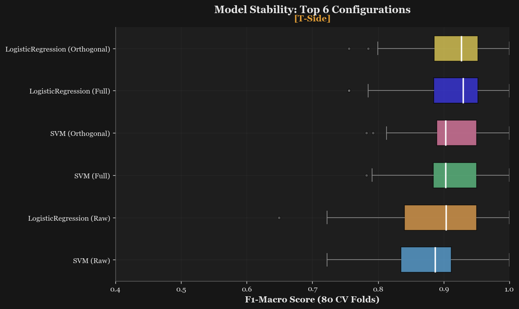

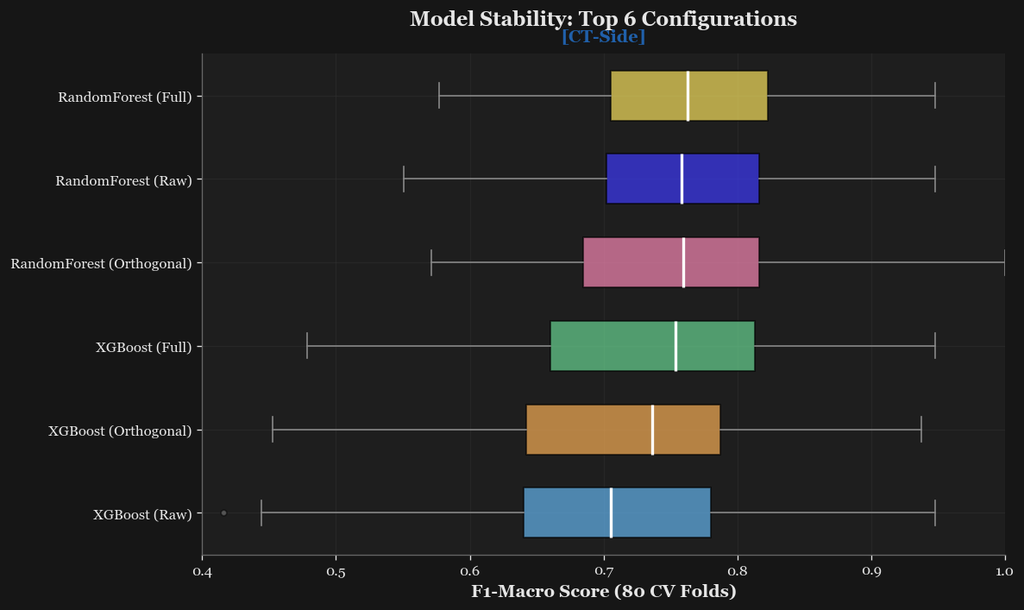

```
======================================================================
CHAMPION MODELS (Best F1-Macro per Side)
======================================================================

T-Side:
  Model: LogisticRegression
  Feature Set: Orthogonal
  F1-Macro: 0.921 ± 0.057
  Accuracy: 0.922 ± 0.054
  Hyperparameters: Default (baseline, no tuning)
  Saved to: P:\cs2-playstyle-analysis-2024\results\classification\models\champion_t_LogisticRegression.joblib

CT-Side:
  Model: RandomForest
  Feature Set: Orthogonal
  F1-Macro: 0.751 ± 0.090
  Accuracy: 0.755 ± 0.087
  Hyperparameters: {'class_weight': 'balanced', 'max_depth': 2, 'max_features': 'sqrt', 'min_samples_leaf': 8, 'n_estimators': 100}
  Saved to: P:\cs2-playstyle-analysis-2024\results\classification\models\champion_ct_RandomForest.joblib

======================================================================
```

### Section 3 Summary & Champion Selection

We evaluated four model families (Logistic Regression, SVM, Random Forest, XGBoost) using nested cross-validation to identify the optimal classifier for each side.

- **Performance:** **F1-Macro 0.751 ± 0.09**
- **Justification:**
  - **Performance vs Interpretability Trade-off:** `Random Forest (Full)` achieved marginally higher mean F1 (0.764) with slightly lower variance (±0.08). However, the 1.3% difference corresponds to ~1 player classification difference across our cohort and falls within confidence overlap.
  - **Why Orthogonal?** We accept the modest variance trade-off (±0.09 vs ±0.08) in exchange for:
    1. A unified feature set with T-side, simplifying cross-interpretation
    2. Avoiding correlated features (ADNT ↔ ADAT) that can cause "vote-splitting" in tree-based importance rankings
    3. Parsimony (6 features vs 7)
  - **Complexity Required:** Tree-based models substantially outperformed the linear baseline (0.75 vs 0.67), confirming CT roles require non-linear decision boundaries.

#### 3. Methodological Note: Constraints for Small Data

Given the small sample size (N=84), we deliberately constrained our tree-based models to use **very shallow depth (max_depth=2-3)** and **high leaf requirements**.

- **Why:** Preliminary tests showed that standard depths (unconstrained or deep trees) allowed models to memorise individual players, leading to train-test gaps of >20%.
- **Result:** By strictly regularising the hyperparameters in our grid search, we maintained healthy train-test gaps (~10%), ensuring the selected champions are learning generalisable role archetypes rather than overfitting to noise.

**Next Steps:** We proceed to **Section 4** to train these two champion models on the full (filtered) dataset. We will then perform a "post-mortem" analysis using **Confusion Matrices** to identify specific misclassification patterns and **SHAP/Coefficient** analysis to validate the behavioural drivers of each role.

## 4. Model Interpretation

**TL;DR:** We analyse Random Forest models for **both** T and CT sides to enable consistent non-linear feature interpretation. We use Gini importance for a global view and SHAP values for directional insights. Finally, we analyse prediction confidence to identify misclassification patterns.

**Why Random Forest for Both Sides?**

Although Logistic Regression was the statistical champion for T-side (F1=0.92), we also analyse the T-side Random Forest (Orthogonal) model here.

**Reasons:**

1. **Consistency:** Using the same model architecture allows for direct comparison of feature importance dynamics between T and CT sides.
2. **Non-Linearity:** Trees can capture complex interactions (e.g., "high aggression is good ONLY IF trading is also high") that linear models miss.
3. **Validation:** If the RF finds similar patterns to the linear model, it reinforces our findings.

**Interpretability Approaches:**

- **Gini Importance:** "Which features are used most often?" (Magnitude)
- **SHAP Values:** "How does this feature value affect the prediction?" (Direction & Magnitude)
- **Confidence Analysis:** "Is the model confused or confidently wrong?" (Error Diagnosis)

### 4.1 Setup & Model Retrieval

We load the existing CT-side champion. For T-side, we retrieve the best hyperparameters from the leaderboard and retrain a fresh Random Forest on the filtered dataset (Core Roles) to ensure fair analysis.

```
Retraining T-Side RandomForest with params: {'class_weight': 'balanced', 'max_depth': 2, 'max_features': 'sqrt', 'min_samples_leaf': 5, 'n_estimators': 100}
Loading saved model from P:\cs2-playstyle-analysis-2024\results\classification\models\champion_ct_RandomForest.joblib

Models ready for interpretation:
  T-Side:  RandomForest (F1 ~0.813)
  CT-Side: RandomForestClassifier (F1 ~0.751)
```

### 4.2 Global Feature Importance (Gini)

We compare which features drive the decision trees for each side. Gini importance measures how often a feature is used to split nodes and how much it reduces impurity.

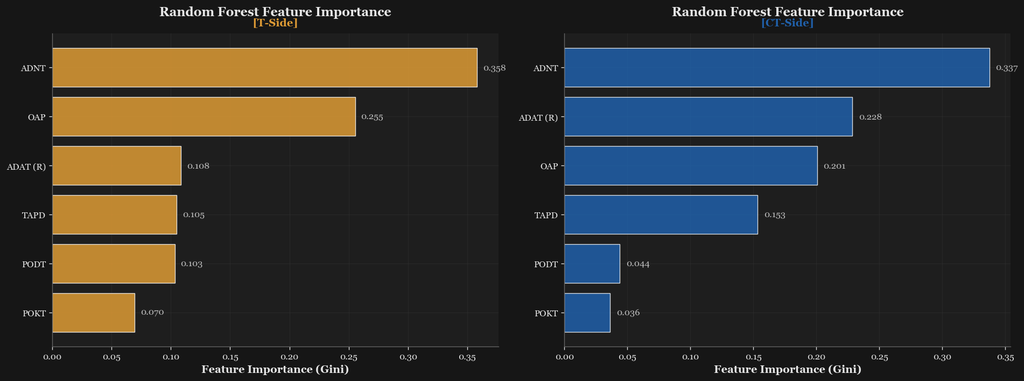

### 4.3 Directional Feature Analysis (SHAP)

Gini importance tells us *what* matters, but not *how*. We use SHAP beeswarm plots to reveal directionality (e.g., does high ADNT predict Lurker or Entry?).

**How to read these plots:**

- **Each Dot:** Represents a single player from the dataset.
- **Rows:** Features (variables).
- **X-axis (SHAP value):** Impact on model output.
  - **Right (Positive):** Pushes prediction *towards* this role.
  - **Left (Negative):** Pushes prediction *away* from this role.
- **Colour:** Actual Feature Value.
  - **Red:** High value for that feature.
  - **Blue:** Low value for that feature.

*Example:* If the "Lurker" plot shows **red dots** (High ADNT) on the **right** (positive SHAP), it means "High isolation increases the probability of being classified as a Lurker".

```
Generating T-Side SHAP Plot...
```

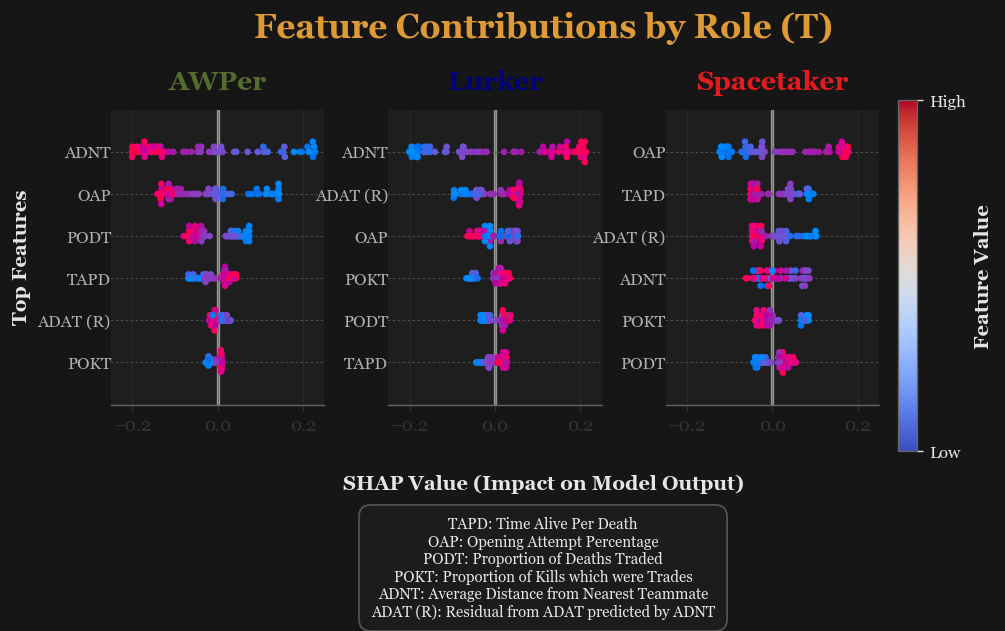

```
Generating CT-Side SHAP Plot...
```

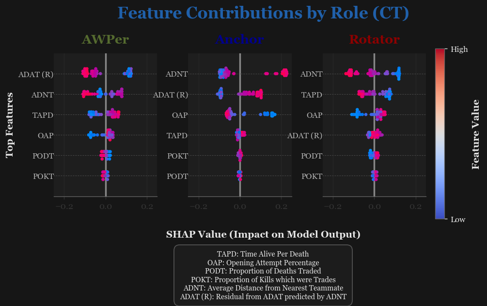

**Observations from SHAP Analysis:**

**T-Side Roles:**

- **Lurker:** Strongly defined by **High ADNT** (Isolation). The red dots on the far right of the ADNT row confirm that isolation is the primary driver. They also show high **ADAT Residuals** meaning they position further away from the team centre than expected (given their ADNT).
- **Spacetaker:** Driven by **High OAP** (Opening Attempts) and **Low TAPD** (Time Alive). This confirms the "entry fragger" profile: aggressive first-contact seeking that often leads to earlier deaths.
- **AWPer:** Characterized by **Low ADNT** (Pack play), **Low OAP** (Opening Attempts) and **High TAPD** (Survival). The blue dots on the ADNT row indicate that playing close to teammates is a key defining feature.

**CT-Side Roles:**

- **Anchor:** The mirror of the Lurker, defined by **High ADNT** (Isolation) and **High ADAT Residuals** (Static/Peripheral holding).
- **Rotator:** Defined by **Low ADNT** (Pack play) and **Low TAPD** (Active rotation/support leading to higher engagement risk).
- **AWPer (CT):** Distinct from T-side AWPers, they show **Higher OAP** (getting more opening picks) but still maintain **High TAPD** (survival), reflecting the "posted up" nature of defensive sniping.

### 4.4 Probability Analysis (The "Discrimination Plot")

We visualise the model's confidence for every player to distinguish between "Clear Wins", "Near Misses", and "Confident Errors".

**Methodology: Repeated Cross-Validation** To ensure robust and unbiased probability estimates, we use **Repeated Stratified K-Fold (4 splits × 20 repeats)**.

1. For each player, we generate 20 independent out-of-sample predictions (trained on the other 75% of data).
2. We average these probabilities to get a stable estimate of the model's confidence.
3. **Error bars** represent the standard deviation across repeats, quantifying the stability of the classification.

High standard deviation indicates that a player's classification is sensitive to the specific training data split (an "Unstable" classification).

```
Generating T-Side Predictions...
```

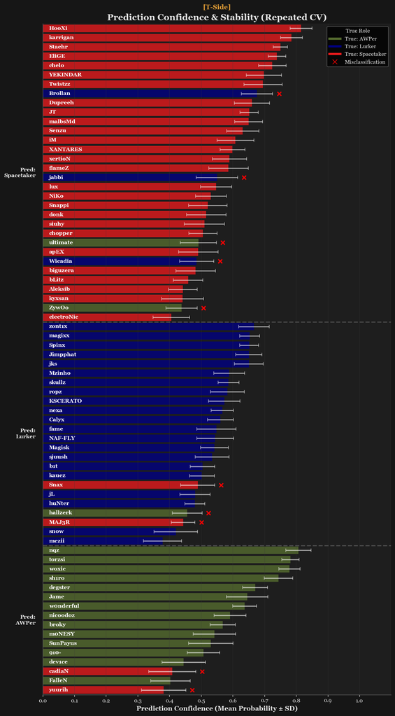

```
Generating CT-Side Predictions...
```

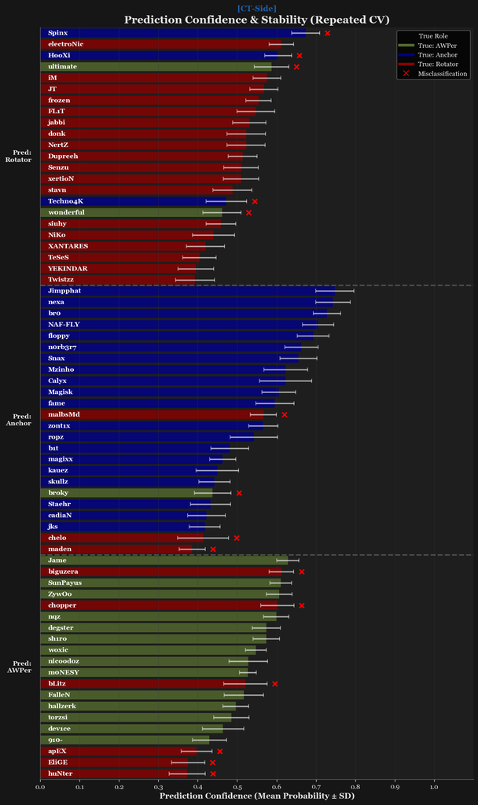

### Observations: Probability & Misclassification Analysis

**Overall Trends:**

As anticipated from the F1 scores and previous analysis, the CT side exhibits a higher rate of misclassification compared to the T side. Specifically, the boundary between **Rotators** and **AWPers** appears the most porous, with the model frequently confusing these roles.

Interestingly, **IGLs appear to be misclassified quite frequently** (HooXi, apEX, chopper, bLitz, Snax, MAJ3R, biguzera), whilst effort was made to use features that did not directly measure personal performance, perhaps there is a confounding effect between IGLs generally performing worse in-game and the distinctiveness of their roles?

**CT-Side Observations and theories:**

- **Spinx (Anchor $\to$ Rotator):** Spinx is the most confidently misclassified player on the CT side. This is a notable case where the model's prediction (Rotator) contradicts the label (Anchor). As discussed in Section 4.5, this likely points to a labelling error in our ground truth rather than a model failure.
- **Ultimate (AWPer $\to$ Rotator):** Consistent with his T-side results, his unique, aggressive AWPing style registers as rifler-like behavior to the model.
- **biguzera (Rotator $\to$ AWPer):** Confidently misclassified as an AWPer, potentially due to being known for taking "Star" positions as an IGL that an AWPer may take.

### 4.5 Individual Misclassification Analysis: Waterfall Plots (LOOCV)

Waterfall plots are generated with a **Leave-One-Out (LOO) fit**: for the player being explained, the model is retrained on all other core-role players (excluding ambiguous roles such as Half-Lurker/Mixed). This mirrors the "unseen player" condition of the CV predictions in Section 4.4 and avoids explaining a model that has already memorised the player. Because the LOO model is slightly better-specified (N-1 > 0.75N), SHAP values may be marginally more confident than any single CV fold, but they faithfully explain why the model would misclassify the player when treated as new data.

Also note **that many of the remarks made here are merely speculative**, and would require individual analysis of the player's matches to be fully justified.

#### T side waterfall plots

We'll start with Brollan and jabbi, Lurkers who were misclassified as Spacetakers.

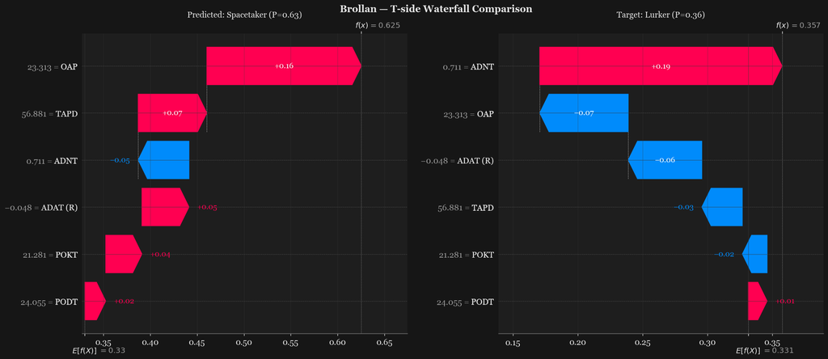

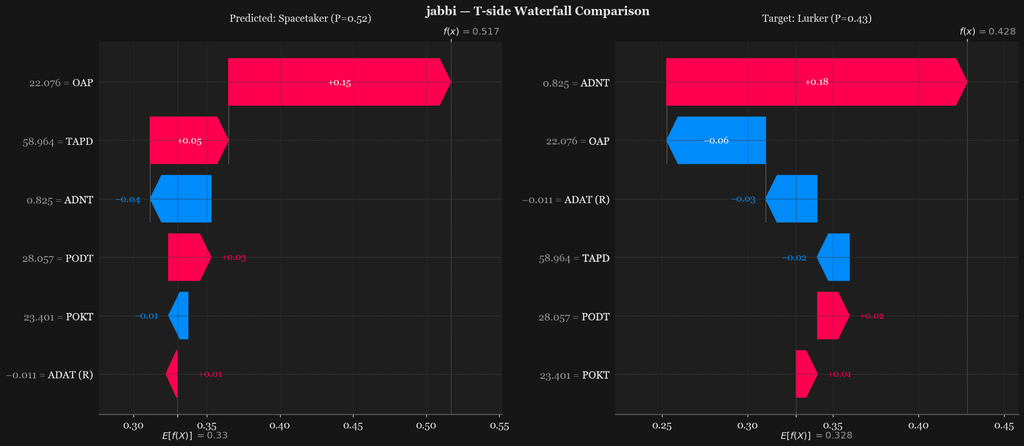

**Brollan** and **jabbi** have relatively similar playstyles according to the feature set. Their main drives towards being predicted as Spacetaker were their high opening attempts (OAP) and low time alive per death (TAPD), both very typical of Spacetakers. Where they deviate is with their high isolation from teammates (ADNT), being the biggest (and virtually only) factor pulling them towards the Lurker role. This tells us that **these players had an isolated but aggresive T-side playstyle.** With such a high distance from their team and with high opening attempts, this could point to a problem with their team keeping up early in the rounds.

Next we'll look at Ultimate, an AWPer who was misclassified as a Spacetaker.

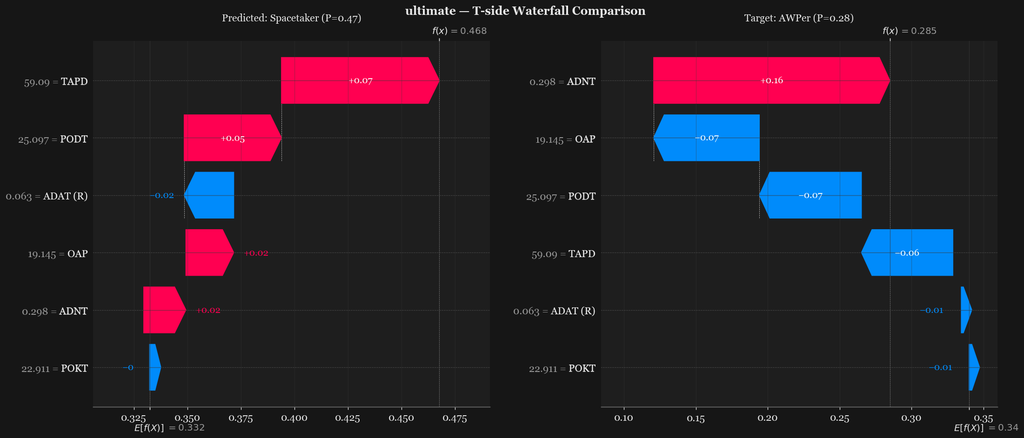

Ultimate was known for being an **exceptionally agressive AWPer** in 2024, and his feature values corroborate this. He was misclassified as a Spacetaker largely due to dying quickly (low TAPD), and being traded relatively frequently (PODT).  
The table below illustrates his feature values compared to other AWPers, he consistently places in the tails of the distribution for all features, indicating he was a significant outlier in his playstyle.

```
Ultimate vs. labelled role (AWPer):
```

|  | player_name | side | role_group | feature | value | percentile | rank |
| --- | --- | --- | --- | --- | --- | --- | --- |
| 0 | ultimate | t | AWPer | tapd_t | 59.090479 | 5.882353 | 1/17 |
| 1 | ultimate | t | AWPer | oap_t | 19.145299 | 94.117647 | 16/17 |
| 2 | ultimate | t | AWPer | podt_t | 25.097174 | 94.117647 | 16/17 |
| 3 | ultimate | t | AWPer | pokt_t | 22.911286 | 11.764706 | 2/17 |
| 4 | ultimate | t | AWPer | adnt_rank_t | 0.298120 | 5.882353 | 1/17 |
| 5 | ultimate | t | AWPer | adat_residual_t | 0.063184 | 88.235294 | 15/17 |

#### CT side waterfall plots

Next we'll look at Spinx, an ""Anchor" who was "misclassified" as a Rotator.

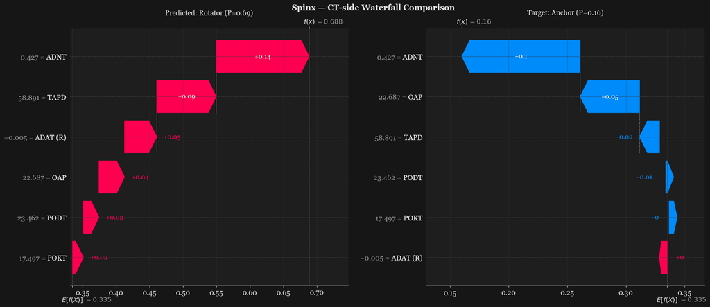

The waterfall plots show that **all of Spinx's features certainly match what one would expect for a Rotator**, and his positioning (ADNT) combined with his opening attempts (OAP) make him very unlikely to be an Anchor. There is a very good reason for this, he is actually misclassified, upon analysing many of his matches from 2024 in Vitality, **Spinx actually did appear to play a rotating role on the CT side.** This is slightly embarassing as it is my fault, at the end of 2024 he switched teams and Harry Richard's positions data (which was used to collect most labels) didn't have him in there, so I must've (wrongly) assumed his CT side role. Whoops! On the plus side, **this demonstrates a potential use case of a model such as this, even if it isn't accurate enough yet to classify all players, it can still highlight potential miscategorisations** such as this.

Next we will look at Hooxi, an Anchor misclassified as a Rotator

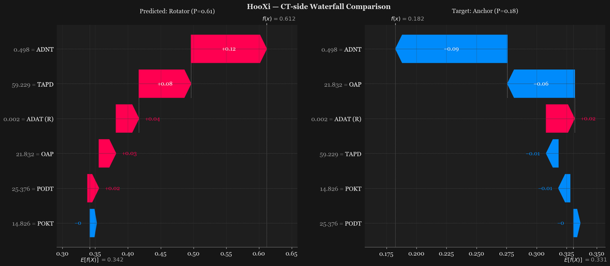

Next we will look at Ultimate (just because he's fun), an AWPer who was misclassified as a Rotator.

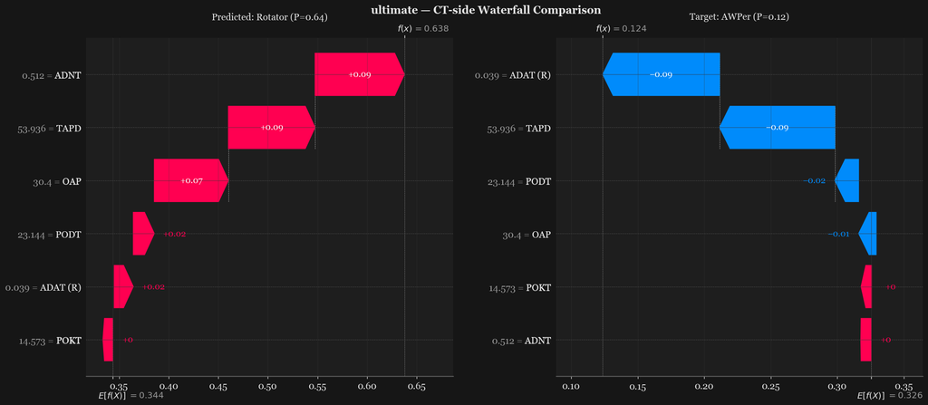

Next we will look at malbsMd, a Rotator who was misclassified as an Anchor.

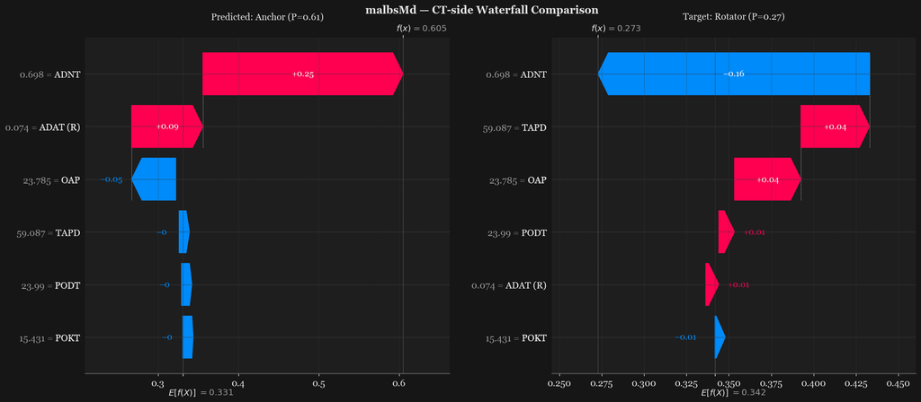

MalbsMd presents a curious case. The drive towards Anchor and away from Rotator is his early round **high isolation from his team**, he positions far from his nearest teammate (ADNT), and even further from his average teammate than one would expect (ADAT Residual). Even looking more specifically at the positions he played on each map, **he did seem to play generally rotate-heavy spots** ["Positions Database"](https://public.tableau.com/app/profile/harry.richards4213/viz/OLDPositionsDatabaseArchived/PositionsDatabaseNER0cs) (e.g. Connector Mirage, Middle Ancient, Connector Anubis). One would have to analyse his specific maps to get a better understanding of this anomaly. My guess would be that in early rounds, more players were stacked closer to the Anchor IGL (HooXi or Snax) to compensate for lower firepower, **leaving malbs more isolated** ["Official: malbsMd joins G2"](https://www.hltv.org/news/39318/official-malbsmd-joins-g2).

Next we'll take a look at biguzera, chopper, bLitz and apEX, all IGL-Rotators who were misclassified as AWPers.

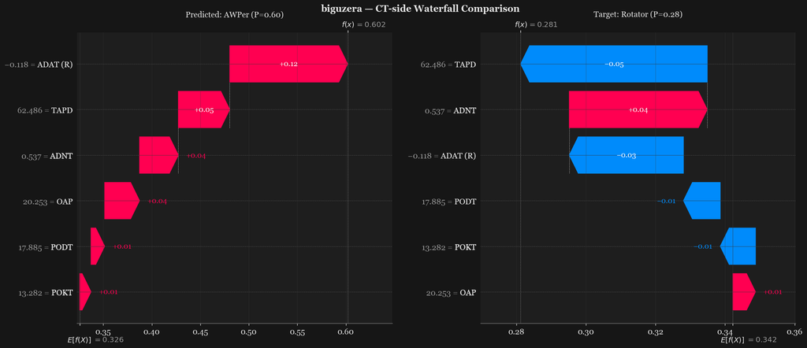

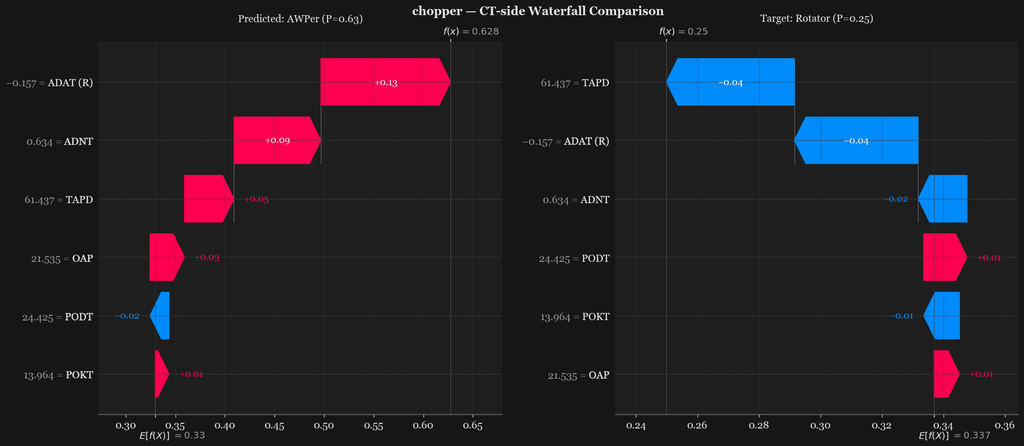

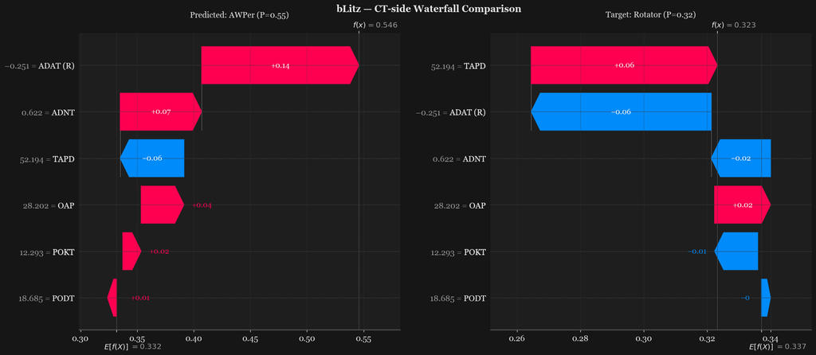

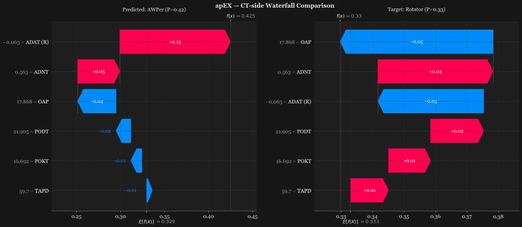

These are the four players most confidently misclassified into the AWPer role (See section 4.4). What makes this interesting is that they are all rotators, and all in-game leaders (IGLs). This seems to be a smoking gun for what went wrong here. Observing their feature values, they all have a low ADAT Residual, pulling them away from being classified as a Rotator and towards the AWPer role.

Lets see if this low ADAT Residual value may have something to do with their meta-role as IGL.

Visual diagnostic: IGL ADAT (Residual) vs CT role distribution

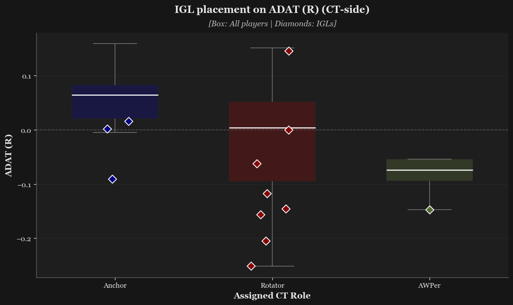

In other words, IGLs tend to play more "Central" positions on the map, atleast early in rounds.

[figure not shown]

This idea is not new, in fact, Harry "NER0cs" Richards points out this centralised-IGL phenomena in his 2024 article:

["Why more and more IGLs are taking up the 'supportive rotator' role"](https://www.hltv.org/news/38747/why-more-and-more-igls-are-taking-up-the-supportive-rotator-role)

The reasoning for this boils down to **how much information the IGL is able to process in these positions**. Central positions allow for IGLs to understand what is happening around the map better, without having to rely on communicated information or a secondary caller (another player designated to lead in specific circumstances). The trade off however, is that a lot of these positions are high-engagement areas, where "Star" players typically excel. Meaning that an IGL can then become a liability, often not pulling their weight in firepower.

### Section 4 Summary & Interpretation

**Key Takeaways:**

- **Feature Utility:** CT-side classification relies on the **four non-trade metrics**, whereas T-side more widely leverages the feature set.
- **The Power of ADNT:** Isolation (`ADNT`) proved to be the most critical feature for almost all roles (except CT AWPers and Spacetakers). While simple and slightly arbitrary, its interpretability and high signal strength make it a standout "bespoke" metric.
- **CT-Side Ambiguity:** The boundary between **Rotators and AWPers** is the most porous in our model. This confusion is likely driven by the **IGL-Centrality phenomena**, where In-Game Leaders play central positions that mimic the spacing profile of snipers.
- **Misclassification as Diagnostic:** High-confidence errors often pointed to ground truth labelling issues (e.g., Spinx, HooXi) or unique outlier playstyles (e.g., Ultimate's aggressive AWPing). Despite the mislabels being "human error" (rushed university coursework!), the model's ability to flag them validates its potential as a viable diagnostic tool for role classification.

**Detailed Interpretations**

**1. Signal Diversity & Feature Starvation**

- **T-Side (Broad Utility):** The model finds useful signal across the entire feature set. Even the lowest-ranked feature (`POKT`) contributes a meaningful 0.07 Gini importance, indicating that trade behavior is a valid discriminator for attacking roles.
- **CT-Side (More Concentrated Signal):** Signal is concentrated in the **four non-trade metrics** (`ADNT`, `ADAT (R)`, `OAP`, `TAPD`). The drop-off for trade metrics (`POKT`, `PODT`) reflects the nature of defensive play: Terrorists typically dictate the terms of engagement, making proactive trading behavior less useful for differentiating between specific CT roles compared to T roles.

**2. Behavioral Drivers (SHAP Analysis)**

- **T-Side:**
  - **Lurker:** Strongly defined by **High Isolation (`ADNT`)**.
  - **Spacetaker:** Defined principally by **High Opening Attempts (`OAP`)** and **Low Survival (`TAPD`)**. Aggresive as expected!
  - **AWPer:** Defined by **Low Isolation (`ADNT`)** and **Low OAP**. Plays passively and close to teammates (Unless their name is Ultimate).
- **CT-Side:**
  - **Anchor:** The mirror of the Lurker, defined by **High Isolation (`ADNT`)**.
  - **Rotator:** Defined by **Low ADNT** (Pack play) and **Low Survival (`TAPD`)**, reflecting the high-engagement nature of rotation play.
  - **AWPer:** Less distinct than T-side. Defined by **Low ADAT Residual** ("Centrality") and **High Survival (`TAPD`)**. Interestingly, `ADNT` signal is mixed, suggesting most AWPers play effectively like rotators while a minority isolate, potentially meaning AWPers may be subcategorised into Rotators and Anchors themselves.

**3. The IGL-Centrality Phenomena**

- A cluster of IGLs (biguzera, chopper, bLitz, apEX) were misclassified as AWPers.
- **Root Cause:** These players consistently show **low `ADAT Residuals`** (positioning closer to the team's centre of mass than expected).
- **Tactical Insight:** I believe this reflects IGLs taking "middle-of-the-pack" positions to gather information. The model confuses this "central" behavior with the positioning of an AWPer.

**4. Future Potential**

- This "first attempt" demonstrates that even with coarse metrics like `OAP` and `ADNT`, we can extract meaningful role signatures.
- The model's ability to identify "outliers" (like Ultimate) and labeling errors (like Spinx) shows its potential. With further refinement, it could be used for classifying a larger number of players (potentially commerically for casual players) or as a supplementary tool for scouting players.

## 5. Synthesis & Conclusion

This notebook has demonstrated that the playstyle features in the dataset contain sufficient signal to classify CS2 professional player roles with high accuracy, particularly on the T-side.

### 5.1 Methodology Recap & Feature Engineering

To ensure statistically robust feature values, we filtered for players with a minimum of **40 maps** used to compute their statistics (as determined in the EDA notebook).

To enable this analysis on a small cohort (N=84), we employed a rigorous **4-split × 20-repeat Nested Cross-Validation** strategy (80 total folds). This ensured that our performance estimates were stable and that our champion models learned generalisable role archetypes rather than memorising individual player data.

A key innovation was the **ADAT (Residual)** feature. By training a global linear regression ($ADNT \to ADAT$) on the stable cohort, we established a "Pro Standard" for how much a player *should* be isolated from the team centre given their distance from their nearest teammate. The residual measures deviation from this professional norm.

**Note on Feature Engineering & Data Leakage**

Technically, *input distribution leakage* exists because the ADAT (Residual) feature is calculated using a global Linear Regression model fit on the entire (stable cohort) dataset (including samples that eventually become "Test" data in Cross-Validation). This means the specific slope and intercept used to transform the features were very slightly influenced by the test subjects, violating the strict separation of Train and Test environments.

Despite this theoretical impurity, the approach is retained and justified for three key reasons:

1. **The "Pro Standard" Baseline (Domain Justification):** We treat the relationship between Isolation (ADNT) and Centrality (ADAT) as a fixed geometric constraint of high-level CS2, defined by the global population of elite professionals. By fitting on the full stable cohort, we establish a canonical "Ground Truth" for standard positioning. The residual, therefore, measures a player's deviation from the professional norm, not just a statistical deviation from a local training fold.
2. **Unsupervised Nature:** The leakage is strictly limited to the relationship between independent variables ($X \to X$). No information regarding the target variable (Player Roles) is leaked. The model is not learning "the answer" from the test set, only the "scale" of the input features.
3. **Feature Stability:** Given the small sample size ($N=84$), calculating regression coefficients within each small CV fold (~63 players) would introduce high variance, causing the definition of the feature to shift wildly between folds. A global fit ensures the feature definition remains consistent and interpretable across the analysis.

### 5.2 Results Synthesis

**Baseline & Feature Sets:**

- Our baseline Logistic Regression significantly outperformed the stratified dummy classifier (Cohen's $d \approx 5.7$ for T-side, $\approx 3.1$ for CT-side), proving that these features capture real playstyle differences, not random noise.
- No clear "winner" emerged among the feature sets (Raw, Orthogonal, Full) at the baseline stage; differences between these sets were within 0.02 F1 (~1-2 players). This justified retaining all three sets for advanced model testing.
- The exclusion of "Ambiguous" roles (Half-Lurker on T-side, Mixed on CT-side) improved F1-Macro by **+0.28 (T)** and **+0.21 (CT)**. This confirms that while "Core" roles (Lurker, Spacetaker, Anchor, Rotator, AWPer) are statistically distinct, the ambiguous roles represent hybrid states that blur the boundaries of our taxonomy.

**Model Performance & Nature:**

- **T-Side:** Best modeled by **Logistic Regression (F1 ≈ 0.92)**. The roles are *linearly separable*, with all features (including trade metrics like `POKT`) contributing useful signal. Simplicity wins here, complex ensembles offered no improvement.
- **CT-Side:** Best modeled by **Random Forest (F1 ≈ 0.75)**. Defensive roles require *non-linear decision boundaries*, relying heavily on just four metrics (positioning and aggression: `ADNT`, `ADAT_Residual`, `OAP`, `TAPD`) while trade metrics provide little discriminatory value.

### 5.3 Key Insights & The "IGL Confound"

The misclassifications themselves provided some of the richest insights:

1. **The "IGL Centrality" Phenomena:** A cluster of Rotator-IGLs (*biguzera, chopper, bLitz, apEX*) were confidently misclassified as AWPers. Our analysis revealed this is due to **Low ADAT Residuals**: IGLs tend to play "central" positions to maximise information processing. The model confuses this centralised support-rotator positioning with the nature of defensive AWPing.
2. **Outliers vs Archetypes:** **Ultimate** stands out as an exceptionally aggressive AWPer. His classification as a Spacetaker/Rotator (despite being an AWPer) highlights his statistical uniqueness, an aggressive sniper (`OAP > 30%`) who breaks the mould of the passive hold.
3. **Diagnostic Value:** High-confidence errors often pointed to ground truth labelling issues (e.g., *Spinx* labelled as Anchor but exhibiting Rotator statistics). This validates the model's potential as a "sanity check" tool for manual labelling efforts.

### 5.4 Conclusion & Future Directions

**Data Integrity Note:** While the base dataset (`data/raw/cs2_playstyle_roles_2024.csv`) has been corrected, this notebook deliberately injected the original errors for **HooXi** and **Spinx**. This "controlled fault injection" allows us to demonstrate the model's diagnostic value: by flagging these players as confident misclassifications (e.g., Spinx confidently predicted as Rotator despite the injected "Anchor" label), the model successfully identified the data quality issues.

This notebook serves as a successful **proof of concept**: player roles in CS2 are not just theoretical labels but measurable statistical clusters. We have provided validation for:

- **A.** The role labels (they correspond to distinct behavioral profiles).
- **B.** The features (they contain discriminatory signal).
- **C.** The modelling approach (ML classification is feasible even with limited data).

It's not perfect—we obviously got some misclassifications even with the best models—but as a first pass at ML role classification, it has served its purpose.

**Limitations & Future Work:**

- **Data Availability:** We are constrained by the organisation of the professional scene. Lower-tier teams often lack the consistent role structures of elite teams (roles may be less distinct or more fluid), and parsing enough maps (>40) for stable metrics is a challenge for teams that don't attend many events. Furthermore, accurate role labels require manual curation (e.g., Harry Richards' lovely Positions Database), which cannot scale to all teams.
- **Feature Expansion:** Future iterations could include weapon-specific features (e.g., "% Kills with AWP" would obviously significantly boost AWPer classification and resolve the Ultimate/IGL confusion) or more granular/creative data that could reveal subtler differences between rifler playstyles.

**Commercial Application:** Finally, this modelling approach has potential for broader application. Integrating role classification into commercial statistic services for casual players (e.g., Leetify, Scope.gg, CSStats) could satisfy the "personal identity" aspect of *Blumler and Katz's Uses and Gratifications Theory*. A feature like "What's my Role" bridges the gap between abstract statistics and personal narrative, giving players a richer understanding of their own gameplay.